# Exploratory Data Analysis of major storms and weather events on Public Health and Economy using NOAA Storm Database in the US

Sreenivasulu Parimi

May 13, 2018

# Reproducible Research: Peer Assessment 2

## 1. Synopsis

Storms and other severe weather events can cause both public health and economic problems for communities and municipalities. Many severe events can result in fatalities, injuries, and property damage, and preventing such outcomes to the extent possible is a key concern.

This project involves exploring the U.S. National Oceanic and Atmospheric Administration’s (NOAA) storm database. This database tracks characteristics of major storms and weather events in the United States, including when and where they occur, as well as estimates of any fatalities, injuries, and property damage.

An analysis of the NOAA Storm Data has been performed with respect to population health and economic consequences due to weather events. The analysis shows that major reason for INJURIES was TORNADOES while main reason for FATALITIES was EXCESSIVE HEAT. Further, it shows that major reason for CROP damage was DROUGHT while main reason for PROPERTY damage was FLASH FLOOD.

## 2. Data Processing

#### 2.1 Load Packages

Load the required packages

```r
library(R.utils)
library(dplyr)
```

```r
library(ggplot2)
library(gridExtra)
```

#### 2.2 Download and Read File

Download the bz2files format data file and unzip if it doesn’t exist.

```r
url <- "https://d396qusza40orc.cloudfront.net/repdata%2Fdata%2FStormData.csv.bz2"
file_name <- "StormData.csv.bz2"
if(!file.exists(file_name)) {
      download.file(url, file_name)
}

if(!file.exists('StormData.csv')) {
      bunzip2("StormData.csv.bz2", overwrite=T, remove=F)
}

raw_storm_data <- read.csv('StormData.csv')
```

#### 2.3 Explore the Storm US Data

Run the required data exploration activities

```r
dim(raw_storm_data)
```

```
## [1] 902297     37
```

```r
head(raw_storm_data, n = 2)
```

```
##   STATE__          BGN_DATE BGN_TIME TIME_ZONE COUNTY COUNTYNAME STATE
## 1       1 4/18/1950 0:00:00     0130       CST     97     MOBILE    AL
## 2       1 4/18/1950 0:00:00     0145       CST      3    BALDWIN    AL
##    EVTYPE BGN_RANGE BGN_AZI BGN_LOCATI END_DATE END_TIME COUNTY_END
## 1 TORNADO         0                                               0
## 2 TORNADO         0                                               0
##   COUNTYENDN END_RANGE END_AZI END_LOCATI LENGTH WIDTH F MAG FATALITIES
## 1         NA         0                        14   100 3   0          0
## 2         NA         0                         2   150 2   0          0
##   INJURIES PROPDMG PROPDMGEXP CROPDMG CROPDMGEXP WFO STATEOFFIC ZONENAMES
## 1       15    25.0          K       0
## 2        0     2.5          K       0
##   LATITUDE LONGITUDE LATITUDE_E LONGITUDE_ REMARKS REFNUM
## 1     3040      8812       3051       8806              1
## 2     3042      8755          0          0              2
```

```r
str(raw_storm_data)
```

```
## 'data.frame':    902297 obs. of  37 variables:
##  $ STATE__   : num  1 1 1 1 1 1 1 1 1 1 ...
##  $ BGN_DATE  : Factor w/ 16335 levels "1/1/1966 0:00:00",..: 6523 6523 4242 11116 2224 2224 2260 383 3980 3980 ...
##  $ BGN_TIME  : Factor w/ 3608 levels "00:00:00 AM",..: 272 287 2705 1683 2584 3186 242 1683 3186 3186 ...
##  $ TIME_ZONE : Factor w/ 22 levels "ADT","AKS","AST",..: 7 7 7 7 7 7 7 7 7 7 ...
##  $ COUNTY    : num  97 3 57 89 43 77 9 123 125 57 ...
##  $ COUNTYNAME: Factor w/ 29601 levels "","5NM E OF MACKINAC BRIDGE TO PRESQUE ISLE LT MI",..: 13513 1873 4598 10592 4372 10094 1973 23873 24418 4598 ...
##  $ STATE     : Factor w/ 72 levels "AK","AL","AM",..: 2 2 2 2 2 2 2 2 2 2 ...
##  $ EVTYPE    : Factor w/ 985 levels "   HIGH SURF ADVISORY",..: 834 834 834 834 834 834 834 834 834 834 ...
##  $ BGN_RANGE : num  0 0 0 0 0 0 0 0 0 0 ...
##  $ BGN_AZI   : Factor w/ 35 levels "","  N"," NW",..: 1 1 1 1 1 1 1 1 1 1 ...
##  $ BGN_LOCATI: Factor w/ 54429 levels "","- 1 N Albion",..: 1 1 1 1 1 1 1 1 1 1 ...
##  $ END_DATE  : Factor w/ 6663 levels "","1/1/1993 0:00:00",..: 1 1 1 1 1 1 1 1 1 1 ...
##  $ END_TIME  : Factor w/ 3647 levels ""," 0900CST",..: 1 1 1 1 1 1 1 1 1 1 ...
##  $ COUNTY_END: num  0 0 0 0 0 0 0 0 0 0 ...
```

[output cut: 23 more lines]

```r
summary(raw_storm_data)
```

```
##     STATE__                  BGN_DATE             BGN_TIME
##  Min.   : 1.0   5/25/2011 0:00:00:  1202   12:00:00 AM: 10163
##  1st Qu.:19.0   4/27/2011 0:00:00:  1193   06:00:00 PM:  7350
##  Median :30.0   6/9/2011 0:00:00 :  1030   04:00:00 PM:  7261
##  Mean   :31.2   5/30/2004 0:00:00:  1016   05:00:00 PM:  6891
##  3rd Qu.:45.0   4/4/2011 0:00:00 :  1009   12:00:00 PM:  6703
##  Max.   :95.0   4/2/2006 0:00:00 :   981   03:00:00 PM:  6700
##                 (Other)          :895866   (Other)    :857229
##    TIME_ZONE          COUNTY           COUNTYNAME         STATE
##  CST    :547493   Min.   :  0.0   JEFFERSON :  7840   TX     : 83728
##  EST    :245558   1st Qu.: 31.0   WASHINGTON:  7603   KS     : 53440
##  MST    : 68390   Median : 75.0   JACKSON   :  6660   OK     : 46802
##  PST    : 28302   Mean   :100.6   FRANKLIN  :  6256   MO     : 35648
##  AST    :  6360   3rd Qu.:131.0   LINCOLN   :  5937   IA     : 31069
##  HST    :  2563   Max.   :873.0   MADISON   :  5632   NE     : 30271
##  (Other):  3631                   (Other)   :862369   (Other):621339
##                EVTYPE         BGN_RANGE           BGN_AZI
##  HAIL             :288661   Min.   :   0.000          :547332
##  TSTM WIND        :219940   1st Qu.:   0.000   N      : 86752
##  THUNDERSTORM WIND: 82563   Median :   0.000   W      : 38446
##  TORNADO          : 60652   Mean   :   1.484   S      : 37558
##  FLASH FLOOD      : 54277   3rd Qu.:   1.000   E      : 33178
##  FLOOD            : 25326   Max.   :3749.000   NW     : 24041
##  (Other)          :170878                      (Other):134990
##          BGN_LOCATI                  END_DATE             END_TIME
##               :287743                    :243411              :238978
##  COUNTYWIDE   : 19680   4/27/2011 0:00:00:  1214   06:00:00 PM:  9802
##  Countywide   :   993   5/25/2011 0:00:00:  1196   05:00:00 PM:  8314
##  SPRINGFIELD  :   843   6/9/2011 0:00:00 :  1021   04:00:00 PM:  8104
##  SOUTH PORTION:   810   4/4/2011 0:00:00 :  1007   12:00:00 PM:  7483
##  NORTH PORTION:   784   5/30/2004 0:00:00:   998   11:59:00 PM:  7184
##  (Other)      :591444   (Other)          :653450   (Other)    :622432
##    COUNTY_END COUNTYENDN       END_RANGE           END_AZI
##  Min.   :0    Mode:logical   Min.   :  0.0000          :724837
##  1st Qu.:0    NA's:902297    1st Qu.:  0.0000   N      : 28082
##  Median :0                   Median :  0.0000   S      : 22510
##  Mean   :0                   Mean   :  0.9862   W      : 20119
##  3rd Qu.:0                   3rd Qu.:  0.0000   E      : 20047
##  Max.   :0                   Max.   :925.0000   NE     : 14606
##                                                 (Other): 72096
```

[output cut: 41 more lines]

```
##  Min.   :   0   Min.   :-14451   Min.   :   0   Min.   :-14455
##  1st Qu.:2802   1st Qu.:  7247   1st Qu.:   0   1st Qu.:     0
##  Median :3540   Median :  8707   Median :   0   Median :     0
##  Mean   :2875   Mean   :  6940   Mean   :1452   Mean   :  3509
##  3rd Qu.:4019   3rd Qu.:  9605   3rd Qu.:3549   3rd Qu.:  8735
##  Max.   :9706   Max.   : 17124   Max.   :9706   Max.   :106220
##  NA's   :47                      NA's   :40
##                                            REMARKS           REFNUM
##                                                :287433   Min.   :     1
##                                                : 24013   1st Qu.:225575
##  Trees down.\n                                 :  1110   Median :451149
##  Several trees were blown down.\n              :   569   Mean   :451149
##  Trees were downed.\n                          :   446   3rd Qu.:676723
##  Large trees and power lines were blown down.\n:   432   Max.   :902297
##  (Other)                                       :588294
```

The raw storm data contains 902297 rows and 37 columns.

#### 2.4 Select Required Observations and Variables for the analysis

We took the following variables those are sufficient for this analysis.

##### Health variables:

1 **FATALITIES**: approx. number of deaths 2 **INJURIES**: approx. number of injuries

##### Economic variables:

1 **PROPDMG**: approx. property damags 2 **PROPDMGEXP**: the units for property damage value 3 **CROPDMG**: approx. crop damages 4 **CROPDMGEXP**: the units for crop damage value

##### Other Variables:

1 **EVTYPE**: weather event (Tornados, Wind, Snow, Flood, etc..) 2 **BGN_DATE**: Years

```r
required_vars <- c( "BGN_DATE", "EVTYPE", "FATALITIES", "INJURIES", "PROPDMG", "PROPDMGEXP", "CROPDMG", "CROPDMGEXP")
tidy_storm_data <- raw_storm_data[, required_vars]
tidy_storm_data$EVTYPE <- toupper(tidy_storm_data$EVTYPE)
```

Added additional new variable called YEAR which stores the proper format of date.

```r
tidy_storm_data$YEAR <- as.numeric(format(as.Date(tidy_storm_data$BGN_DATE, format = "%m/%d/%Y %H:%M:%S"), "%Y"))
```

The events in the database start in the year 1950 and end in November 2011. In the earlier years of the database there are generally fewer events recorded, most likely due to a lack of good records. More recent years should be considered more complete.

Look at the histogram of the data Yearly wise:

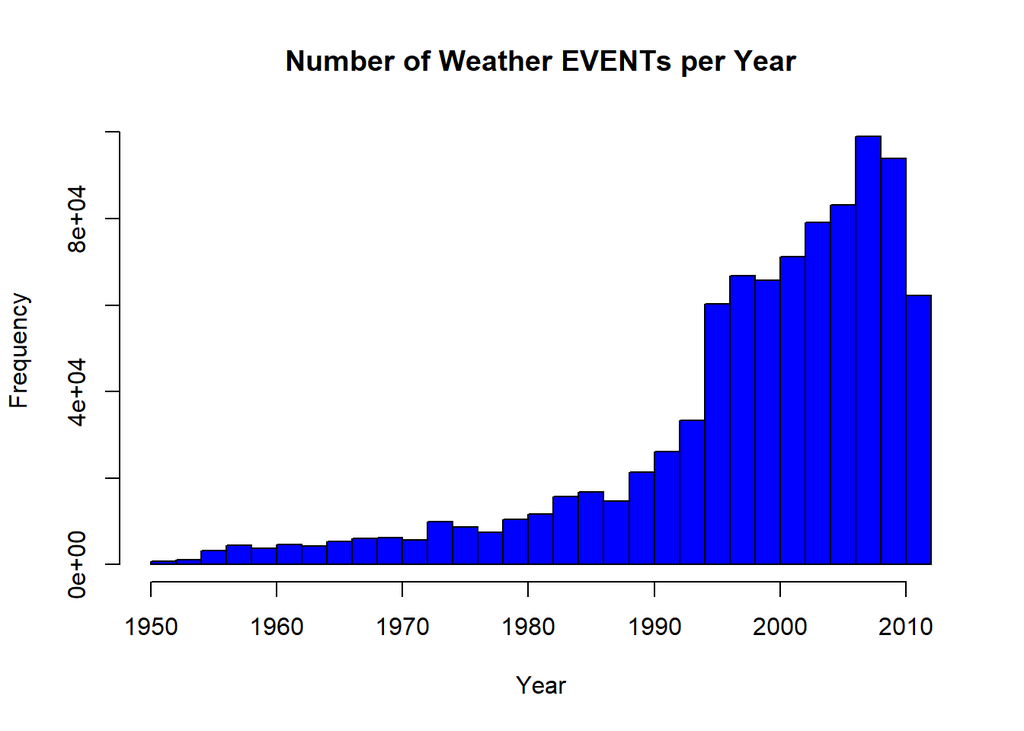

```r
hist(tidy_storm_data$YEAR, col = "blue", breaks = 30, main="Number of Weather EVENTs per Year", xlab="Year", ylab="Frequency")
```

As for the above histogram, we can see that the number of events tracked starts to significantly increase from around 1990. So, we can use the subset of the data from 1990 to 2011 to get most out of good records.

```r
tidy_storm_data <- tidy_storm_data[tidy_storm_data$YEAR >= 1990, ]
dim(tidy_storm_data)
```

```
## [1] 751740      9
```

Look for the blank values in the data:

```r
sum(is.na(tidy_storm_data$BGN_DATE))
```

```
## [1] 0
```

```r
sum(is.na(tidy_storm_data$EVTYPE))
```

```
## [1] 0
```

```r
sum(is.na(tidy_storm_data$INJURIES))
```

```
## [1] 0
```

```r
sum(is.na(tidy_storm_data$PROPDMG))
```

```
## [1] 0
```

```r
sum(is.na(tidy_storm_data$PROPDMGEXP))
```

```
## [1] 0
```

```r
sum(is.na(tidy_storm_data$CROPDMG))
```

```
## [1] 0
```

```r
sum(is.na(tidy_storm_data$CROPDMGEXP))
```

```
## [1] 0
```

#### 2.5 Handling Exponential variables PROPDMGEXP and CROPDMGEXP

we can see that the PROPDMG and CROPDMG variables each one has an associated EXP variable. We need to handle this so that we can have numbers that we can use. The factors we need to handle with are:

```r
levels(tidy_storm_data$PROPDMGEXP)
```

```
##  [1] ""  "-" "?" "+" "0" "1" "2" "3" "4" "5" "6" "7" "8" "B" "h" "H" "K"
## [18] "m" "M"
```

```r
levels(tidy_storm_data$CROPDMGEXP)
```

```
## [1] ""  "?" "0" "2" "B" "k" "K" "m" "M"
```

We can write a function which calculates the actual cost taking into account the correct exponent. The conversion is based on the information found at [How To Handle Exponent Value of PROPDMGEXP and CROPDMGEXP](https://rstudio-pubs-static.s3.amazonaws.com/58957_37b6723ee52b455990e149edde45e5b6.html).

```r
exp_calc <- function(x, exponent) {
      if (exponent %in% c("h", "H"))
            return(x * (10 ** 2))
      else if (exponent %in% c("k", "K"))
            return(x * (10 ** 3))
      else if (exponent %in% c("m", "M"))
            return(x * (10 ** 6))
      else if (exponent %in% c("b", "B"))
            return(x * (10 ** 9))
      else if (!is.na(as.numeric(exponent)))
            return(x * (10 ** as.numeric(exponent)))
      else if (exponent %in% c("+"))
            return(x * 10)
      else if (exponent %in% c("", "-", "?"))
            return(x) # Actually x * 10^0 = x * 1 = x
      else {
            stop("It is not a valid value")
      }
}
```

Now we can use the mapply function along with the exp_calc function to calculate the actual damage costs for crops and properties and store the results in two new variables CROPDMG_calc and PROPDMG_calc respectively:

```r
tidy_storm_data$PROPDMG_calc <- mapply(exp_calc, tidy_storm_data$PROPDMG, tidy_storm_data$PROPDMGEXP)
tidy_storm_data$CROPDMG_calc <- mapply(exp_calc, tidy_storm_data$CROPDMG, tidy_storm_data$CROPDMGEXP)
dim(tidy_storm_data)
```

```
## [1] 751740     11
```

```r
head(tidy_storm_data)
```

```
##               BGN_DATE    EVTYPE FATALITIES INJURIES PROPDMG PROPDMGEXP
## 4408  1/5/1990 0:00:00      HAIL          0        0     0.0
## 4409 1/20/1990 0:00:00 TSTM WIND          0        0     0.0
## 4410 1/20/1990 0:00:00 TSTM WIND          0        0     0.0
## 4411 1/25/1990 0:00:00 TSTM WIND          0        0     0.0
## 4412 1/25/1990 0:00:00   TORNADO          0       28     2.5          M
## 4413 1/25/1990 0:00:00 TSTM WIND          0        0     0.0
##      CROPDMG CROPDMGEXP YEAR PROPDMG_calc CROPDMG_calc
## 4408       0            1990            0            0
## 4409       0            1990            0            0
## 4410       0            1990            0            0
## 4411       0            1990            0            0
## 4412       0            1990      2500000            0
## 4413       0            1990            0            0
```

Now the tidy Storm Data contains 751740 rows and 11 columns.

#### 2.6 Processed Data Summary

Now we can store the final required summarised data in a tibble.

```r
tidy_storm_data_summary <- tidy_storm_data %>%
      group_by(EVTYPE) %>%
      summarise( total_fatalities = sum(FATALITIES), total_injuries = sum(INJURIES),
total_properties_damage = sum(PROPDMG_calc), total_crop_damage = sum(CROPDMG_calc) )

dim(tidy_storm_data_summary)
```

```
## [1] 898   5
```

```r
head(tidy_storm_data_summary)
```

```
## # A tibble: 6 x 5
##   EVTYPE total_fatalities total_injuries total_propertie~ total_crop_dama~
##   <chr>             <dbl>          <dbl>            <dbl>            <dbl>
## 1 "   H~               0.             0.          200000.               0.
## 2 " COA~               0.             0.               0.               0.
## 3 " FLA~               0.             0.           50000.               0.
## 4 " LIG~               0.             0.               0.               0.
## 5 " TST~               0.             0.         8100000.               0.
## 6 " TST~               0.             0.            8000.               0.
```

## 3. Results

##### 3.1 Across the United States, which types of events (as indicated in the `EVTYPE` variable) are most harmful with respect to population health?

Fetch the top 5 causes of fatalities and store the results in a new tibble:

```r
fatalities <- tidy_storm_data_summary %>%
      arrange_(~ desc(total_fatalities)) %>%
      select(EVTYPE, total_fatalities) %>%
      slice(1:5)
```

Fetch the top 5 causes of injuries and store the results in a new tibble:

```r
injuries <- tidy_storm_data_summary %>%
      arrange_(~ desc(total_injuries)) %>%
      select(EVTYPE, total_injuries) %>%
      slice(1:5)
```

Plotting the data for visualization:

[figure not shown]

```r
# First plot
plot1 <- ggplot(data = injuries, aes(x = reorder(EVTYPE, total_injuries), y = total_injuries)) + geom_bar(fill = "blue", stat = "identity") + coord_flip() + ylab("Total number of injuries") + xlab("Event type") + ggtitle("Fatalities and injuries caused by weather in the US - Top 10") + theme(legend.position = "none")

# Second plot
plot2 <- ggplot(data = fatalities, aes(x = reorder(EVTYPE, total_fatalities), y = total_fatalities)) + geom_bar(fill = "red", stat = "identity") + coord_flip() + ylab("Total number of fatalities") + xlab("Event type") + theme(legend.position = "none")

# Combine both plots in a grid
grid.arrange(plot1, plot2, nrow = 2)
```

The above plot shows that the `EXCESSIVE HEAT` and `TORNADO` were caused most FATALITIES while `TORNADO` caused most INJURIES in the US from 1990 to 2011.

##### 3.2 Across the United States, which types of events have the greatest economic consequences?

Fetch the top 5 causes of crop damage and store the results in a new tibble:

```r
crop_damage <- tidy_storm_data_summary %>%
      arrange_(~ desc(total_crop_damage)) %>%
      select(EVTYPE, total_crop_damage) %>%
      slice(1:5)
```

Fetch the top 5 causes of properties damage and store the results in a new tibble:

```r
prop_damage <- tidy_storm_data_summary %>%
      arrange_(~ desc(total_properties_damage)) %>%
      select(EVTYPE, total_properties_damage) %>%
      slice(1:5)
```

Plot the data for visualization:

[figure not shown]

```r
# First plot
plot3 <- ggplot(data = crop_damage, aes(x = reorder(EVTYPE, total_crop_damage), y = total_crop_damage)) + geom_bar(fill = "blue", stat = "identity") + coord_flip() + ylab("Economic consequence of crop damage in USD") + xlab("Event type") + ggtitle("Crop and property damage caused by weather in the US - Top 10") + theme(legend.position = "none")

# Second plot
plot4 <- ggplot(data = prop_damage, aes(x = reorder(EVTYPE, total_properties_damage), y = total_properties_damage)) + geom_bar(fill = "red", stat = "identity") + coord_flip() + ylab("Economic consequence of property damage in USD") + xlab("Event type") + theme(legend.position = "none")

# Combine both plots in a grid
grid.arrange(plot3, plot4, nrow = 2)
```

The above plot shows that the `DROUGHT` and `FLOOD` were caused most CROP damage while `FLASH FLOOD` and `THUNDERSTORM WINDS` were caused most PROPERTY damage in the US from 1990 to 2011.